# Practical Machine Learning

Praveer

Saturday, July 25, 2015

# background

Using devices such as Jawbone Up, Nike FuelBand, and Fitbit it is now possible to collect a large amount of data about personal activity relatively inexpensively. In this project, our goal is to use data from accelerometers on the belt, forearm, arm, and dumbell of 6 participants. They were asked to perform barbell lifts correctly and incorrectly in 5 different ways. We will predict the manner in which they did the excercise.

# Download and clean data and Do pre-processing

Install and Load the required packages

```r
library(caret)
```

```r
library(rpart)
library(rpart.plot)
library(randomForest)
library(corrplot)
library(e1071)
```

Load and Clean Data

```r
trainset <- read.csv("./pml-training.csv")
testset <- read.csv("./pml-testing.csv")
dim(trainset)
```

```
## [1] 19622   160
```

```r
dim(testset)
```

```
## [1]  20 160
```

```r
sum(complete.cases(trainset))
```

```
## [1] 406
```

```r
trainset <- trainset[, colSums(is.na(trainset)) == 0]
testset <- testset[, colSums(is.na(testset)) == 0]


classe <- trainset$classe
trainclean <- grepl("^X|timestamp|window", names(trainset))
trainset <- trainset[, !trainclean]
trainfinal <- trainset[, sapply(trainset, is.numeric)]
trainfinal$classe <- classe
testclean <- grepl("^X|timestamp|window", names(testset))
testset <- testset[, !testclean]
testfinal <- testset[, sapply(testset, is.numeric)]

dim(trainfinal)
```

```
## [1] 19622    53
```

```r
dim(testfinal)
```

```
## [1] 20 53
```

the cleaned training data set contains 19622 observations and 53 variables. The cleaned testing data set contains 20 observations and 53 variables. The “classe” variable is to be the predicted variable.

## Further split the training data in training and coss validation (CV) sets

```r
set.seed(11111)
inTrain <- createDataPartition(trainfinal$classe, p=0.70, list=F)
trainData <- trainfinal[inTrain, ]
validationData <- trainfinal[-inTrain, ]
```

# Applying Random Forest Model for prediction

we use the training data to fit a model and use the validation data to evaluate the model strength. And also asses the overall model accuracy.

```r
## train randomForest

controlRf <- trainControl(method="cv", 5)
modelRf <- train(classe ~ ., data=trainData, method="rf", trControl=controlRf, ntree=250)
modelRf
```

```
## Random Forest
##
## 13737 samples
##    52 predictor
##     5 classes: 'A', 'B', 'C', 'D', 'E'
##
## No pre-processing
## Resampling: Cross-Validated (5 fold)
##
## Summary of sample sizes: 10991, 10988, 10990, 10990, 10989
##
## Resampling results across tuning parameters:
##
##   mtry  Accuracy   Kappa      Accuracy SD  Kappa SD
##    2    0.9897361  0.9870148  0.002363215  0.002990762
##   27    0.9895177  0.9867388  0.002431737  0.003075382
##   52    0.9839854  0.9797396  0.005451208  0.006894740
##
## Accuracy was used to select the optimal model using  the largest value.
## The final value used for the model was mtry = 2.
```

```r
## Validate prediction

predictRf <- predict(modelRf, validationData)
confusionMatrix(validationData$classe, predictRf)
```

```
## Confusion Matrix and Statistics
##
##           Reference
## Prediction    A    B    C    D    E
##          A 1674    0    0    0    0
##          B    8 1126    5    0    0
##          C    0    5 1021    0    0
##          D    0    0   15  948    1
##          E    0    0    4    2 1076
##
## Overall Statistics
##
##                Accuracy : 0.9932
##                  95% CI : (0.9908, 0.9951)
##     No Information Rate : 0.2858
##     P-Value [Acc > NIR] : < 2.2e-16
##
##                   Kappa : 0.9914
##  Mcnemar's Test P-Value : NA
##
## Statistics by Class:
##
##                      Class: A Class: B Class: C Class: D Class: E
## Sensitivity            0.9952   0.9956   0.9770   0.9979   0.9991
## Specificity            1.0000   0.9973   0.9990   0.9968   0.9988
## Pos Pred Value         1.0000   0.9886   0.9951   0.9834   0.9945
## Neg Pred Value         0.9981   0.9989   0.9951   0.9996   0.9998
## Prevalence             0.2858   0.1922   0.1776   0.1614   0.1830
## Detection Rate         0.2845   0.1913   0.1735   0.1611   0.1828
## Detection Prevalence   0.2845   0.1935   0.1743   0.1638   0.1839
## Balanced Accuracy      0.9976   0.9964   0.9880   0.9973   0.9989
```

```r
accuracy <- postResample(predictRf, validationData$classe)
accuracy
```

```
##  Accuracy     Kappa
## 0.9932031 0.9914012
```

```r
outofsample <- 1 - as.numeric(confusionMatrix(validationData$classe, predictRf)$overall[1])
outofsample
```

```
## [1] 0.006796941
```

Thus the model is 99.3% effective with a .6% probable error in prediction. This is a very high accuracy and we can safely select this model to apply to our final test set.

# Final predictions on Test Data

```r
Final <- predict(modelRf, testfinal[, -length(names(testfinal))])
Final
```

```
##  [1] B A B A A E D B A A B C B A E E A B B B
## Levels: A B C D E
```

# Plots for Visualization

## Corelation Matrix

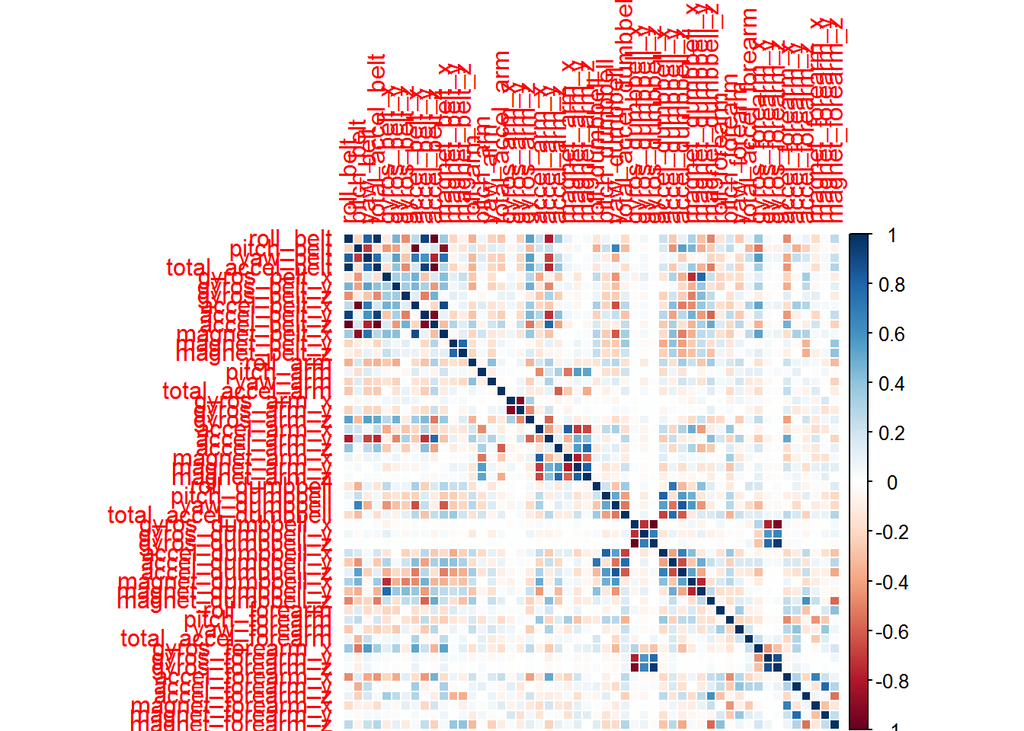

```r
corrPlot <- cor(trainData[, -length(names(trainData))])
corrplot(corrPlot, method="color")
```

## Decision tree

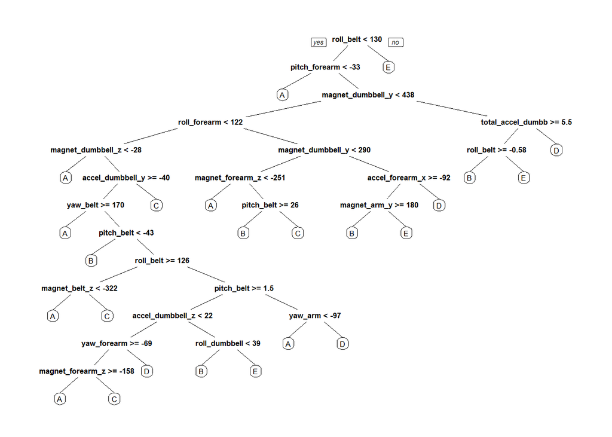

```r
treeModel <- rpart(classe ~ ., data=trainData, method="class")
prp(treeModel)
```

# Write Predictions to Files for submission

```r
answers <- Final
pml_write_files <- function(x){
  n = length(x)
  for(i in 1:n){
    filename = paste0("problem_id_",i,".txt")
    write.table(x[i], file=filename, quote=FALSE,
                row.names=FALSE, col.names=FALSE)
  }
}
pml_write_files(answers)
```